# Analisando os dados para criar um modelo de evasão de Alunos

```python
import pandas as pd
from sqlalchemy import create_engine
import matplotlib.pyplot as plt
import seaborn as sns
```

```python
!pip install python-dotenv matplotlib seaborn
```

```
  Using cached python_dotenv-1.0.1-py3-none-any.whl.metadata (23 kB)
Using cached python_dotenv-1.0.1-py3-none-any.whl (19 kB)
```

```python
import os
from dotenv import load_dotenv

# Carrega as variáveis de ambiente do arquivo .env
load_dotenv(dotenv_path="../.env_dev")
```

```
True
```

### Conexão com o Banco de Dados

```python
def create_conn():
    # Defina os parâmetros de conexão
    db_user = os.getenv('DB_USER')
    db_password = os.getenv('DB_PASSWORD')
    db_host = os.getenv('DB_HOST')
    db_port = '5432'
    db_name = 'magic-steps'

    # Crie a URL de conexão
    connection_url = f'postgresql://{db_user}:{db_password}@{db_host}:{db_port}/{db_name}'

    # Crie um engine do SQLAlchemy
    engine = create_engine(connection_url)
    return engine
engine = create_conn()
```

## Query que carrega os dados da vw_aluno

View Criada para ter uma visão mais completa dos alunos

```python
query = """
SELECT *
FROM magic_steps.vw_aluno
"""

df = pd.read_sql_query(query, engine)
df.head()
```

|  | IdAluno | IdUnidade | Sexo | EstadoCivil | DataNascimento | CorRaca | EnsinoMedio_IdEstabelecimentoEnsino | EnsinoMedio_AnoConclusao | IdTurma | IdSituacaoAlunoTurma | ... | IdMotivoInativacao | ComentarioInativacao | IdPlanoPagamento_Matricula | MotivoInativacao | SituacaoAlunoTurma | idade | DataOcorrencia | ObservacaoRegistro | IdTipoOcorrencia | NomeTipoOcorrencia |
| --- | --- | --- | --- | --- | --- | --- | --- | --- | --- | --- | --- | --- | --- | --- | --- | --- | --- | --- | --- | --- | --- |
| 0 | 145 | 1.0 | M | 5.0 | 2005-11-26 02:00:00 | B | None | None | 303 | 9 | ... | NaN |  | 9.0 | None | Troca de Fase *Anual | 18.0 | 2021-08-18 00:00:00 | Aluno foi transferido da Turma 4A para a 4F, p... | 12 | *Mudança de Turma* |
| 1 | 145 | 1.0 | M | 5.0 | 2005-11-26 02:00:00 | B | None | None | 226 | 9 | ... | NaN |  | NaN | None | Troca de Fase *Anual | 18.0 | 2021-08-18 00:00:00 | Aluno foi transferido da Turma 4A para a 4F, p... | 12 | *Mudança de Turma* |
| 2 | 145 | 1.0 | M | 5.0 | 2005-11-26 02:00:00 | B | None | None | 222 | 9 | ... | NaN |  | NaN | None | Troca de Fase *Anual | 18.0 | 2021-08-18 00:00:00 | Aluno foi transferido da Turma 4A para a 4F, p... | 12 | *Mudança de Turma* |
| 3 | 145 | 1.0 | M | 5.0 | 2005-11-26 02:00:00 | B | None | None | 202 | 9 | ... | NaN |  | 9.0 | None | Troca de Fase *Anual | 18.0 | 2021-08-18 00:00:00 | Aluno foi transferido da Turma 4A para a 4F, p... | 12 | *Mudança de Turma* |
| 4 | 145 | 1.0 | M | 5.0 | 2005-11-26 02:00:00 | B | None | None | 105 | 9 | ... | NaN |  | 8.0 | None | Troca de Fase *Anual | 18.0 | 2021-08-18 00:00:00 | Aluno foi transferido da Turma 4A para a 4F, p... | 12 | *Mudança de Turma* |

5 rows × 24 columns

### Mostrar as primeiras linhas do DataFrame e verificar informações básicas

```python
df_info = df.info()
df_head = df.head()

df_info, df_head
```

```
<class 'pandas.core.frame.DataFrame'>
RangeIndex: 146899 entries, 0 to 146898
Data columns (total 24 columns):
 #   Column                               Non-Null Count   Dtype
---  ------                               --------------   -----
 0   IdAluno                              146899 non-null  int64
 1   IdUnidade                            146899 non-null  float64
 2   Sexo                                 146899 non-null  object
 3   EstadoCivil                          146899 non-null  float64
 4   DataNascimento                       146899 non-null  object
 5   CorRaca                              146899 non-null  object
 6   EnsinoMedio_IdEstabelecimentoEnsino  0 non-null       object
 7   EnsinoMedio_AnoConclusao             0 non-null       object
 8   IdTurma                              146899 non-null  int64
 9   IdSituacaoAlunoTurma                 146899 non-null  int64
```

[output cut: 16 more lines]

```
(None,
    IdAluno  IdUnidade Sexo  EstadoCivil       DataNascimento CorRaca  \
 0      145        1.0    M          5.0  2005-11-26 02:00:00       B
 1      145        1.0    M          5.0  2005-11-26 02:00:00       B
 2      145        1.0    M          5.0  2005-11-26 02:00:00       B
 3      145        1.0    M          5.0  2005-11-26 02:00:00       B
 4      145        1.0    M          5.0  2005-11-26 02:00:00       B

   EnsinoMedio_IdEstabelecimentoEnsino EnsinoMedio_AnoConclusao  IdTurma  \
 0                                None                     None      303
 1                                None                     None      226
 2                                None                     None      222
 3                                None                     None      202
 4                                None                     None      105

```

[output cut: 29 more lines]

Percebemos que algumas colunas estão nulas, por isso decidimos removê-las.

Também notamos que as colunas de data estão no formato `object`, então iremos convertê-las para `datetime`.

```python
# Remover colunas com muitos valores nulos
cols_to_drop = [
    'EnsinoMedio_IdEstabelecimentoEnsino',
    'EnsinoMedio_AnoConclusao',
    'ComentarioInativacao'
]
df_clean = df.drop(columns=cols_to_drop)

# Converter colunas de datas para datetime
date_cols = [
    'DataNascimento',
    'DataSituacaoAtivo',
    'DataSituacaoInativo',
    'DataHoraEfetivacaoMatricula',
    'DataOcorrencia'
]

for col in date_cols:
    df_clean[col] = pd.to_datetime(df_clean[col], errors='coerce')

# Verificar dados limpos
df_clean_info = df_clean.info()
df_clean_head = df_clean.head()

df_clean_info, df_clean_head
```

```
<class 'pandas.core.frame.DataFrame'>
RangeIndex: 146899 entries, 0 to 146898
Data columns (total 21 columns):
 #   Column                       Non-Null Count   Dtype
---  ------                       --------------   -----
 0   IdAluno                      146899 non-null  int64
 1   IdUnidade                    146899 non-null  float64
 2   Sexo                         146899 non-null  object
 3   EstadoCivil                  146899 non-null  float64
 4   DataNascimento               146899 non-null  datetime64[ns]
 5   CorRaca                      146899 non-null  object
 6   IdTurma                      146899 non-null  int64
 7   IdSituacaoAlunoTurma         146899 non-null  int64
 8   DataSituacaoAtivo            146896 non-null  datetime64[ns]
 9   DataSituacaoInativo          114766 non-null  datetime64[ns]
 10  DataHoraEfetivacaoMatricula  146896 non-null  datetime64[ns]
 11  ProblemaAutorizadoMatricula  146899 non-null  object
 12  IdMotivoInativacao           13955 non-null   float64
 13  IdPlanoPagamento_Matricula   118462 non-null  float64
 14  MotivoInativacao             13955 non-null   object
 15  SituacaoAlunoTurma           146899 non-null  object
 16  idade                        146899 non-null  float64
 17  DataOcorrencia               146899 non-null  datetime64[ns]
 18  ObservacaoRegistro           146899 non-null  object
 19  IdTipoOcorrencia             146899 non-null  int64
 20  NomeTipoOcorrencia           146899 non-null  object
dtypes: datetime64[ns](5), float64(5), int64(4), object(7)
memory usage: 23.5+ MB
```

```
(None,
    IdAluno  IdUnidade Sexo  EstadoCivil      DataNascimento CorRaca  IdTurma  \
 0      145        1.0    M          5.0 2005-11-26 02:00:00       B      303
 1      145        1.0    M          5.0 2005-11-26 02:00:00       B      226
 2      145        1.0    M          5.0 2005-11-26 02:00:00       B      222
 3      145        1.0    M          5.0 2005-11-26 02:00:00       B      202
 4      145        1.0    M          5.0 2005-11-26 02:00:00       B      105

    IdSituacaoAlunoTurma DataSituacaoAtivo DataSituacaoInativo  ...  \
 0                     9        2022-01-01          2022-12-31  ...
 1                     9        2022-01-01          2022-12-31  ...
 2                     9        2022-01-01          2022-12-31  ...
 3                     9        2022-01-01          2022-12-31  ...
 4                     9        2021-01-01          2021-12-31  ...

```

[output cut: 29 more lines]

### Alunos distintos

Como essa view contem varias linhas por aluno, pois carrega informações como todas as ocorrências dos alunos.

```python
df_distinct = df_clean.drop_duplicates(subset='IdAluno')
```

```python
# Configurações de visualização
sns.set_theme(style="whitegrid", palette="pastel")
sns.color_palette("pastel")
```

### Distribuição de Sexo

Percebemos que existe uma pequena diferença na quantidade de mulheres na base, mas que está muito próxima da representação demográfica do Brasil.

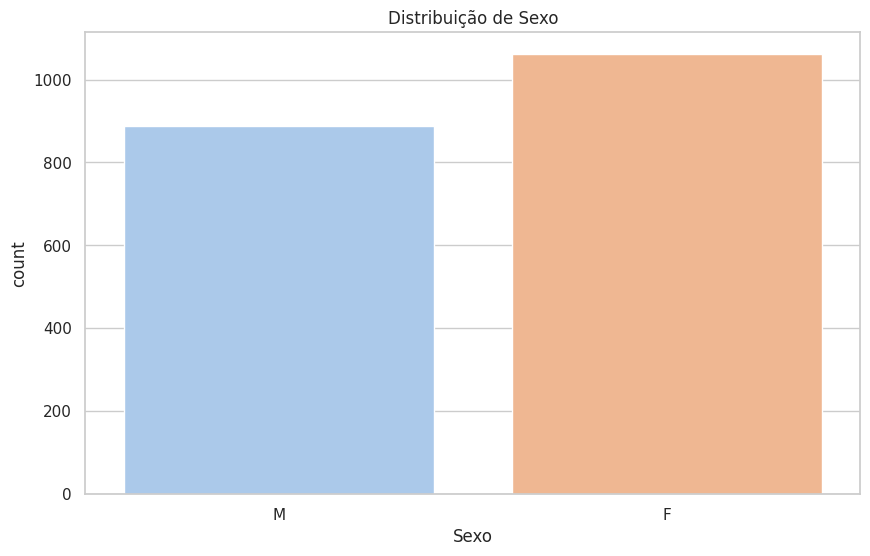

```python
# Distribuição de Sexo
plt.figure(figsize=(10, 6))
sns.countplot(data=df_distinct, x='Sexo', hue='Sexo', palette="pastel")
plt.title('Distribuição de Sexo')
plt.show()
```

### Distribuição de Cor/Raça

Vemos no gráfico abaixo uma maior representação de pessoas Brancas e Pardas

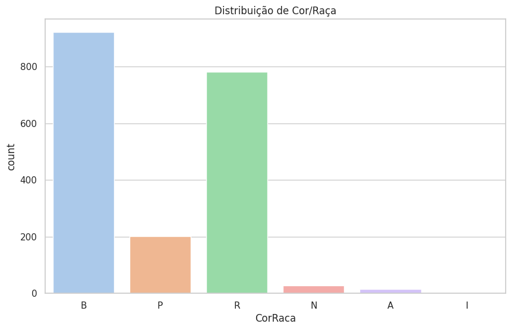

```python
# Distribuição de Cor/Raça
plt.figure(figsize=(10, 6))
sns.countplot(data=df_distinct, x='CorRaca', hue='CorRaca', palette="pastel")
plt.title('Distribuição de Cor/Raça')
plt.show()
```

### Distribuição de Situação do Aluno na Turma

Analisando a distribuição total da base, percebemos que existe uma grande quantidade de alunos desistentes.

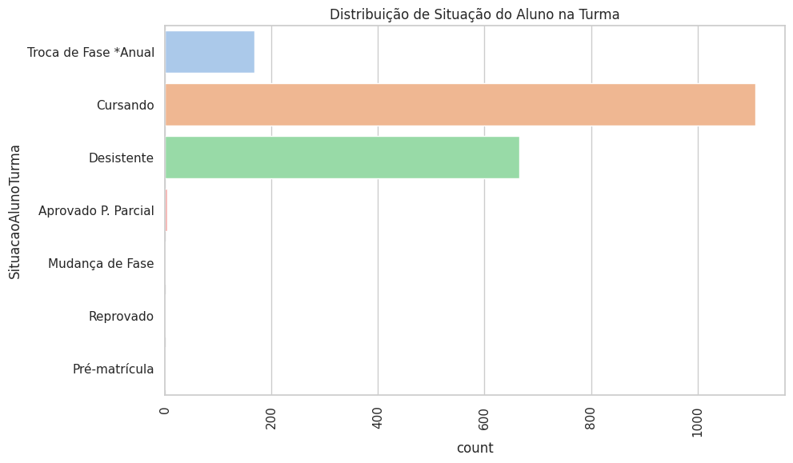

```python
# Distribuição de Situação do Aluno na Turma
plt.figure(figsize=(10, 6))
sns.countplot(data=df_distinct, y='SituacaoAlunoTurma', hue='SituacaoAlunoTurma', palette="pastel")
plt.title('Distribuição de Situação do Aluno na Turma')
plt.xticks(rotation=90)
plt.show()
```

### Distribuição de Motivo de Inativação

Nesta análise, estamos considerando a base completa, pois existem mais de uma informação de inativação por aluno. Chamou nossa atenção que alguns dos principais motivos de inativação foram: `Conhecimento acima da fase atual`, `Outras prioridades/trabalho`, e `Falta de retorno às nossas tentativas de contato`. O motivo `Mudou de bairro/cidade/distância`, mesmo sendo um dos principais, é fácil de entender do ponto de vista do aluno.

No entanto, ao analisar o motivo `Falta de retorno`, surgem algumas dúvidas: Será que existe uma visita presencial para verificar a situação do(a) aluno(a)? São consideradas possíveis dificuldades tecnológicas para contato do lado do aluno?

Sobre o motivo `Outras prioridades/trabalho`, para os alunos que trabalham, será que existe uma abordagem que possa ajudar esses alunos, como cargas horárias menores ou maior empatia com suas situações?

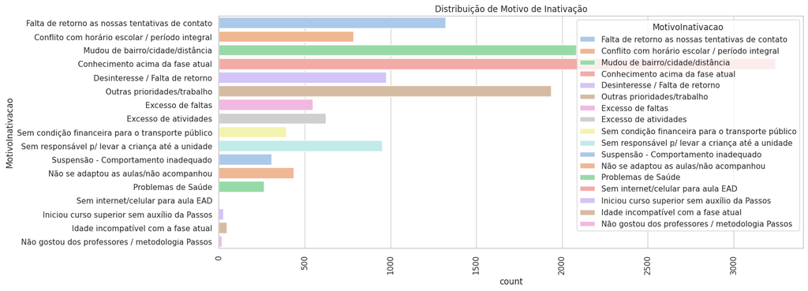

```python
# Distribuição de Motivo de Inativação
plt.figure(figsize=(15, 6))
sns.countplot(data=df_clean, y='MotivoInativacao', hue='MotivoInativacao', palette="pastel")
plt.title('Distribuição de Motivo de Inativação')
plt.xticks(rotation=90)
plt.show()
```

### Distribuição do Top 10 dos Nomes do Tipo de Ocorrência

Analisando as principais ocorrências para entender se esse tipo de informação tem alguma correlação com a inativação.

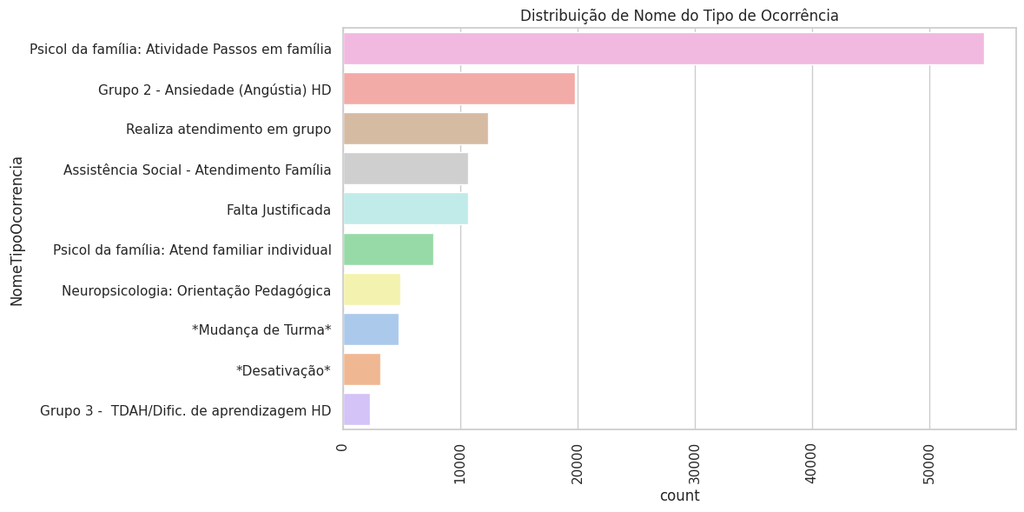

```python
# Distribuição do Top 10 dos Nomes do Tipo de Ocorrência

# Filtro apenas o top 10
top_10_motivos = df_clean['NomeTipoOcorrencia'].value_counts().nlargest(10).index
df_top_10 = df_clean[df_clean['NomeTipoOcorrencia'].isin(top_10_motivos)]


plt.figure(figsize=(10, 6))
sns.countplot(data=df_top_10, y='NomeTipoOcorrencia',hue='NomeTipoOcorrencia',  palette="pastel", order=df_top_10['NomeTipoOcorrencia'].value_counts().index)
plt.title('Distribuição de Nome do Tipo de Ocorrência')
plt.xticks(rotation=90)
plt.show()
```

### Distribuição de Idade

Nesta análise usamos os dados distintos, para entender apenas a distribuição de idade na base.

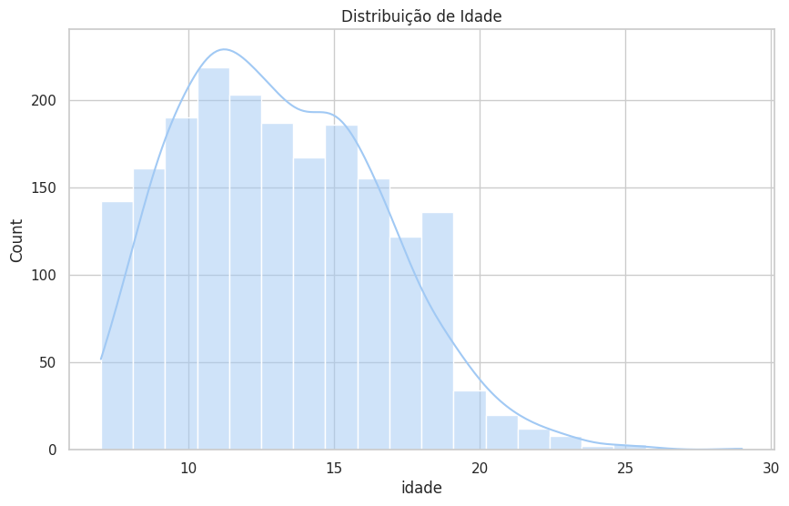

```python
# Distribuição de Idade
plt.figure(figsize=(10, 6))
sns.histplot(data=df_distinct, x='idade', bins=20, kde=True)
plt.title('Distribuição de Idade')
plt.show()
```

### Analise de Correlação

Antes de executar a correlação precisamos transformar as colunas categóricas em numéricas

```python
# Selecionando as colunas categóricas
categorical_cols = ['Sexo', 'CorRaca', 'SituacaoAlunoTurma', 'MotivoInativacao', 'NomeTipoOcorrencia']

# Converter colunas categóricas para numéricas
for col in categorical_cols:
    df_clean[col] = df_clean[col].astype('category').cat.codes

# Validando conversão
df_clean[categorical_cols].head()
```

|  | Sexo | CorRaca | SituacaoAlunoTurma | MotivoInativacao | NomeTipoOcorrencia |
| --- | --- | --- | --- | --- | --- |
| 0 | 1 | 1 | 6 | -1 | 4 |
| 1 | 1 | 1 | 6 | -1 | 4 |
| 2 | 1 | 1 | 6 | -1 | 4 |
| 3 | 1 | 1 | 6 | -1 | 4 |
| 4 | 1 | 1 | 6 | -1 | 4 |

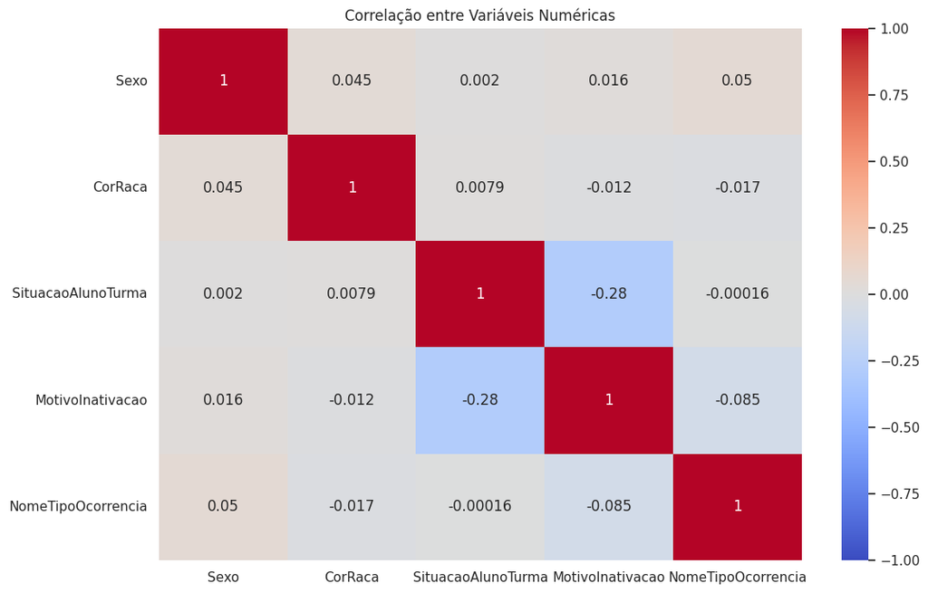

```python
plt.figure(figsize=(12, 8))
sns.heatmap(df_clean[categorical_cols].corr(), annot=True, cmap='coolwarm', vmin=-1, vmax=1)
plt.title('Correlação entre Variáveis Numéricas')
plt.show()
```

## Conclusão da Primeira Análise

Observamos que, embora as features selecionadas forneçam informações importantes sobre os alunos, elas, isoladamente, não apresentam uma boa correlação com a inativação. Com isso, decidimos retornar à análise da base de dados e selecionar novas informações que possuam uma correlação mais significativa.